# Project Proposal

Author

Group 3

# 1 Motivation

The rapid expansion of financial technology platforms has generated large volumes of customer data, creating opportunities to better understand user behaviour and financial engagement. Effectively analysing this data is essential for identifying patterns in customer usage, preferences, and interactions with financial services.

This project is motivated by the need to translate complex customer data into meaningful and accessible visualisations and insights. By exploring demographic characteristics, financial activity, and service usage, we will uncover key trends and differences across customer groups.

Additionally, we will emphasise the importance of interactive analytical tools in making data exploration more intuitive. By enabling users to dynamically explore and interpret data, we will support deeper understanding and more informed decision-making.

# 2 Objectives

This project aims to develop an interactive visualisation tool that enables users to explore and interpret patterns within Colombian fintech customer data, providing a clear and structured understanding of customer behaviour.

- **Comprehensive Customer Analysis:**  
  We will analyse demographic characteristics, financial behaviour, and service usage to uncover key patterns, variations, and segment-level differences within the fintech customer base.
- **Integrated Pattern and Relationship Exploration:**  
  We will examine relationships across multiple variables to identify how customer attributes and behaviours interact, revealing broader trends and underlying dynamics in the data.
- **Insight Facilitation and User-Driven Exploration:**  
  We will highlight key findings identified during the analysis while enabling users to independently explore the data through the Shiny application, supporting deeper interpretation and allowing these insights to serve as a reference for analysing similar datasets or their own business contexts.

# 3 Data

This project utilises the **COFINFAD: Colombian Fintech Financial Analytics Dataset**, which consists of two primary data files: *customer_data.csv* and *transactions_data.csv*. These datasets are linked through a common identifier, “customer_id”. The data will be imported into R using the `read_csv()` function from the **readr** package.

The *customer.csv* dataset will serve as the primary dataset for this project. Each row represents an individual customer, while each column captures different aspects of the customer’s profile and behaviour. The dataset provides a comprehensive view across multiple dimensions, including:

- **Demographic characteristics** (e.g., age, gender, location, income bracket, education level, marital status)
- **Financial product ownership** (e.g., savings accounts, credit cards, loans, investment and insurance products)
- **Digital engagement metrics** (e.g., app login frequency, feature usage)
- **Aggregated transaction behaviour** (e.g., number of transactions, average transaction value, total transaction volume, transaction frequency, first and last transaction dates)
- **Customer experience indicators** (e.g., satisfaction scores, Net Promoter Score, app ratings, feedback sentiment)
- **Customer lifecycle and support metrics** (e.g., tenure, support tickets, complaint categories, estimated customer lifetime value)

The *transaction.csv* dataset, while available, will not be central to the analysis. Although it contains detailed records of individual transactions, key transaction-related measures have already been aggregated at the customer level. As the project focuses on customer-level patterns and insights, the customer dataset sufficiently supports the analytical objectives.

The transactions dataset will only be utilised if more granular, transaction-level exploration becomes necessary.

# 4 Methodology & Analytical Approach

This project adopts a combination of **Exploratory Data Analysis (EDA)** and **Confirmatory Data Analysis (CDA)** to analyse patterns, relationships, and variations in Colombian fintech customer data.

The project is structured into three analytical modules within the Shiny application, namely **Exploratory Data Analysis**, **Confirmatory Data Analysis**, and **Segmentation (Clustering Analysis)**. While EDA and CDA form the core analytical approaches, clustering will be implemented as part of the CDA framework to identify distinct customer segments.

We will highlight key insights derived from the analysis while designing the application to support **user-driven exploration**, enabling users to independently investigate patterns and relationships within the dataset.

## 4.1 **Exploratory Data Analysis**

For this project, EDA will be conducted primarily through visualisation techniques to enable users to derive insights through interactive visual analytics. The availability of demographic, financial, behavioural, and engagement-related variables provides a multi-dimensional view of fintech customer behaviour.

We will explore variable distributions, compare customer segments, and identify patterns across variables. These exploratory insights will guide both the confirmatory analysis and the design of the Shiny application.

## 4.2 **Confirmatory Data Analysis**

For this project, CDA will be conducted in two main components.

First, we will perform hypothesis testing to assess the statistical significance of relationships and differences between variables. This includes tests such as t-tests, ANOVA, chi-square tests, and their non-parametric equivalents where appropriate.

Second, we will conduct segmentation analysis using clustering techniques to identify distinct customer groups based on their demographics, transactional behaviours, product usage, satisfaction, and location (city)-based patterns. This will provide deeper insights into the underlying structure of the dataset.

Together, these methods will ensure that key findings are statistically supported and analytically robust.

## 4.3 Segmentation Analysis

To ensure both statistical rigor and computational efficiency, the module employs two primary clustering algorithms tailored to different data types:

- **K-Means Clustering:** Utilized for **Transactional, and Satisfaction** data. Since these metrics are purely numeric (e.g., transaction volume, NPS scores), K-Means provides a fast, scalable way to define segments based on Euclidean distance.
- **CLARA (Clustering Large Applications):** Utilized for **Demographic and Product Usage** data. Because these datasets contain “mixed” data (e.g., age vs. categorical occupations), we employ the CLARA algorithm with **Gower Distance**. This approach is specifically optimized for large datasets, preventing memory crashes while accurately handling categorical variables.

# 5 Data Visualisation Methods

The Shiny application will consist of three main modules designed to support both guided insights and user-driven exploration:

- Variable Distribution Analysis
- Comparative Analysis
- Segmentation Analysis

These modules are structured to provide an intuitive analytical flow, allowing users to first understand individual variables, then explore relationships, and finally identify meaningful customer segments.

## 5.1 Variable Distribution Analysis (Univariate Analysis)

This module will focus on understanding the distribution and characteristics of individual variables using exploratory data analysis (EDA). As there are no predefined benchmarks, confirmatory analysis will not be applicable.

The analysis will be structured into key categories:

- **Demographics:** We will use bar charts for categorical variables and histograms/boxplots for numerical variables to understand the composition of the customer base.
- **Transaction Behaviour:** We will use histograms, density plots, and boxplots to examine distributions, along with bar charts for categorical variables such as transaction type.
- **Product Ownership & App Usage:** We will use bar charts to analyse adoption of financial products and platform engagement features.
- **Customer Satisfaction:** We will use histograms and boxplots for numerical metrics, and bar charts for sentiment-related variables.
- **Text Analysis:** We will preprocess text data (e.g., feature requests, complaint topics) and use bar charts to highlight the most frequent themes.

## 5.2 Comparative Analysis (Bivariate and Multivariate Analysis)

This module will examine relationships between variables using both visual and statistical techniques.

- **Categorical vs Numerical:** We will use boxplots, violin/raincloud plots, and ridgeline plots to compare distributions across groups. Statistical tests (e.g., ANOVA or Kruskal–Wallis) will be applied to assess significance.
- **Numerical vs Numerical:** We will use scatter plots with trend lines to visualise relationships, supported by correlation-based analysis.
- **Categorical vs Categorical:** We will use stacked bar charts and mosaic plots to examine associations, with chi-square tests applied for validation.
- **Multivariate Overview:** We will use a correlation matrix to provide a summary of relationships across multiple numerical variables.

## 5.3 Segmentation Analysis

The module allows users to explore five specific dimensions of the Colombian market:

- **Demographics:** Segmenting by age, occupation, and household size.
- **Behavioral & Transactional:** Identifying “Power Users” vs. “Occasional Users” based on transaction frequency and credit utilization.
- **Product Usage:** Grouping customers by their specific mix of credit cards, savings accounts, and insurance products.
- **Satisfaction & Engagement:** Isolating segments with low sentiment or high support ticket ratios to identify churn risks.
- **Location-Based Personas:** A hybrid approach using **K-Means combined with Treemap visualizations** to show how specific personas (e.g., “Young Digitals” or “High-Value Seniors”) are distributed across major cities like Bogotá, Medellín, and Cali.

It also includes real-time model quality metrics. Users can adjust the number of clusters and variables via the Shiny interface, immediately receiving feedback through:

- **AIC/BIC Scores:** For evaluating model fit in numeric clusters.
- **Silhouette Width & Entropy:** To measure the stability and separation of demographic and geographic segments.

# 6 R Packages Used

The R packages we will be using for the project include:

| **Package** | **Description** |
| --- | --- |
| tidyverse | For data import, cleaning, and manipulation |
| ggplot2 (part of tidyverse) | For creating static data visualisations |
| plotly | For interactive, publication-quality plots |
| ggiraph | For adding interactivity (e.g., tooltips) to ggplot2 visualisations |
| ggpubr | For creating publication-ready plots and adding statistical test results |
| ggstatsplot | For visualisations integrated with statistical testing |
| ggdist | For distribution visualisations such as raincloud plots |
| ggridges | For ridgeline plots to compare distributions across groups |
| ggmosaic | For visualising relationships between categorical variables using mosaic plots |
| tidytext | For text processing and analysis of textual variables |
| shiny, shinydashboard, shinythemes | For developing, structuring, and styling the interactive Shiny application |
| cluster | For clustering, `clara()` is optimized for >40k rows, avoiding memory crashes. |
| factoextra | For visualising PCA-based cluster plots and Elbow/Silhouette methods. |
| fpc | Used to calculate Entropy and cluster stability |
| treemap | Allows for a “nested” look at how behavioral clusters sit within Planning Regions/Locations. |

# 7 Story Board

**Introduction**

The Shiny app will open to the Introduction page, which will talk about the usability of the app and give an overview of the variables in the dataset with the values of the key variables identified.

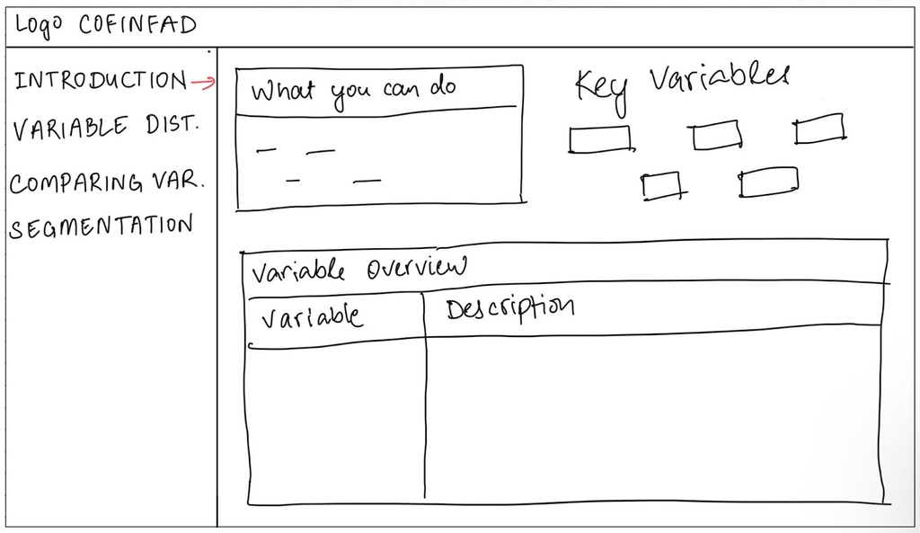

**Variable Distribution**

This page will allow the user to select the variable and view its distribution. The page will be divided into the overall categories of the variables in the dataset, such as demographic, transactions, products, app usage and satisfaction.

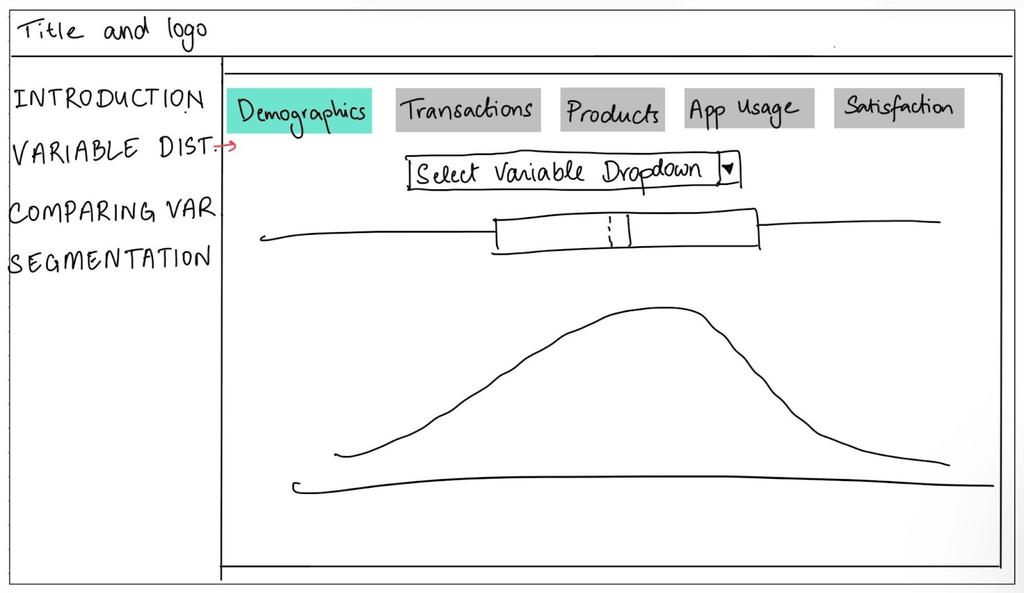

**Comparing Variables**

On this page, users will be able to analyse how two variables interact with each other in the bivariate subsection, while the multivariate section will allow them to see how all the numeric variables interact with each other using a correlogram.

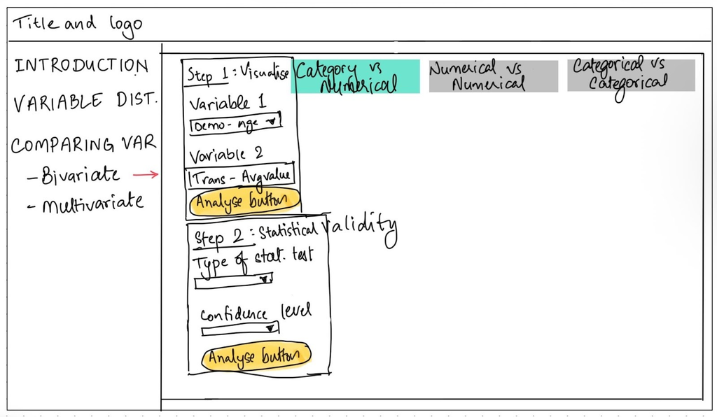

**Segmentation**

This page allows users to view how customers are segmented based on different categories. For each category, users can adjust the number of clusters and variables, and view the corresponding cluster plot and quality metrics.

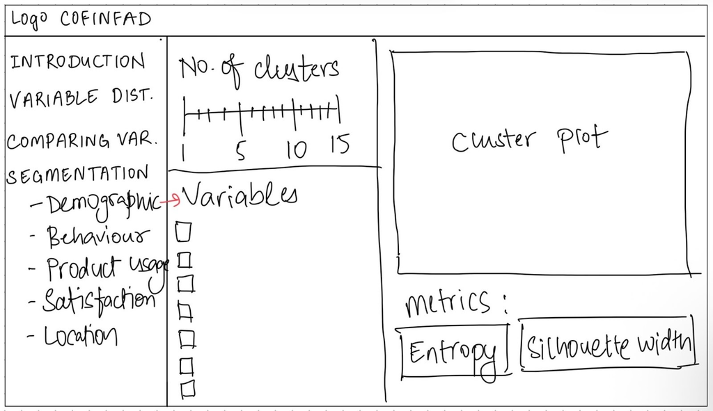

# 8 Scope of Work

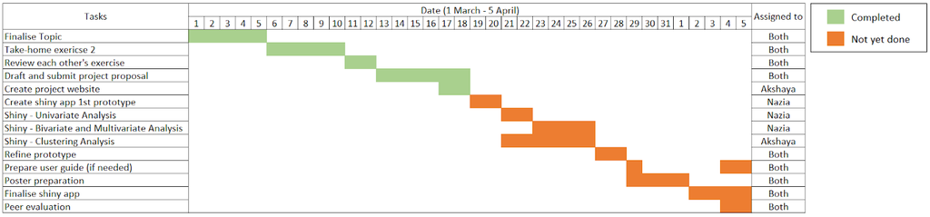